# Assigning ASVs with DADA2

Chloe J. McGovern

March 09, 2025

#Goals

1. Infer errors in the sequences, separately on the forward and reverse reads.
2. Assign ASVs on both the forward and reverse reads, separately. Apply the error model.
3. Merge the forward and reverse ASVs into “contiguous ASVs”.
4. Generate our first draft of our ASV count table.
5. Quality trimming of ASV lengths.
6. Remove chimeras.
7. Assign Taxonomy with Silva Database. . Write out relevant files: `asv_table` , `asvs_fasta` , and `sample_data` .

#Input

1. Filtered fastq files generated from `01_QualityTrimming.Rmd`
2. Sample Name vector.

##Output 1. `asv_table` 2. `asvs_fasta` 3. `tax_table` 4. `sample_data`

#Set up the environment

## Set the seed

```r
#reproducibility
set.seed(6572)

#Parameter for thread number
n_threads = 20
```

#Timing the script This will tell us how long it took to run the file on the class server.

```r
start_time <- Sys.time()
```

## Load packages

```r
pacman::p_load(tidyverse, devtools, dada2,
               patchwork, DT, install=FALSE)
```

#Load filtered Fastq files

```r
# Place filtered seq files into a variable
filtered_fastqs_path <- "data/01_DADA2/02_filtered_fastqs"

# Intuition check:
filtered_fastqs_path
```

```
## [1] "data/01_DADA2/02_filtered_fastqs"
```

```r
#Create forward vector
filtered_forward_reads <-
  list.files(filtered_fastqs_path, pattern = "R1_filtered.fastq.gz" ,
             full.names = TRUE)

#Check
filtered_forward_reads[1:5]
```

```
## [1] "data/01_DADA2/02_filtered_fastqs/SRR9722160_R1_filtered.fastq.gz"
## [2] "data/01_DADA2/02_filtered_fastqs/SRR9722161_R1_filtered.fastq.gz"
## [3] "data/01_DADA2/02_filtered_fastqs/SRR9722162_R1_filtered.fastq.gz"
## [4] "data/01_DADA2/02_filtered_fastqs/SRR9722163_R1_filtered.fastq.gz"
## [5] "data/01_DADA2/02_filtered_fastqs/SRR9722164_R1_filtered.fastq.gz"
```

```r
#Reverse vector
filtered_reverse_reads <-
  list.files(filtered_fastqs_path, pattern = "R2_filtered.fastq.gz" ,
             full.names = TRUE)

#Check
filtered_reverse_reads
```

```
##  [1] "data/01_DADA2/02_filtered_fastqs/SRR9722160_R2_filtered.fastq.gz"
##  [2] "data/01_DADA2/02_filtered_fastqs/SRR9722161_R2_filtered.fastq.gz"
##  [3] "data/01_DADA2/02_filtered_fastqs/SRR9722162_R2_filtered.fastq.gz"
##  [4] "data/01_DADA2/02_filtered_fastqs/SRR9722163_R2_filtered.fastq.gz"
##  [5] "data/01_DADA2/02_filtered_fastqs/SRR9722164_R2_filtered.fastq.gz"
##  [6] "data/01_DADA2/02_filtered_fastqs/SRR9722165_R2_filtered.fastq.gz"
##  [7] "data/01_DADA2/02_filtered_fastqs/SRR9722166_R2_filtered.fastq.gz"
##  [8] "data/01_DADA2/02_filtered_fastqs/SRR9722167_R2_filtered.fastq.gz"
##  [9] "data/01_DADA2/02_filtered_fastqs/SRR9722168_R2_filtered.fastq.gz"
## [10] "data/01_DADA2/02_filtered_fastqs/SRR9722169_R2_filtered.fastq.gz"
## [11] "data/01_DADA2/02_filtered_fastqs/SRR9722170_R2_filtered.fastq.gz"
## [12] "data/01_DADA2/02_filtered_fastqs/SRR9722171_R2_filtered.fastq.gz"
## [13] "data/01_DADA2/02_filtered_fastqs/SRR9722172_R2_filtered.fastq.gz"
## [14] "data/01_DADA2/02_filtered_fastqs/SRR9722173_R2_filtered.fastq.gz"
## [15] "data/01_DADA2/02_filtered_fastqs/SRR9722174_R2_filtered.fastq.gz"
## [16] "data/01_DADA2/02_filtered_fastqs/SRR9722175_R2_filtered.fastq.gz"
## [17] "data/01_DADA2/02_filtered_fastqs/SRR9722176_R2_filtered.fastq.gz"
## [18] "data/01_DADA2/02_filtered_fastqs/SRR9722177_R2_filtered.fastq.gz"
## [19] "data/01_DADA2/02_filtered_fastqs/SRR9722178_R2_filtered.fastq.gz"
## [20] "data/01_DADA2/02_filtered_fastqs/SRR9722179_R2_filtered.fastq.gz"
```

#Assign sample names

```r
# Create vector of sample names from the filenames
sample_names <- sapply(strsplit(basename(filtered_forward_reads), "_"), `[`,1)

# Intuition Check
head(sample_names)
```

```
## [1] "SRR9722160" "SRR9722161" "SRR9722162" "SRR9722163" "SRR9722164"
## [6] "SRR9722165"
```

# Error modeling

```r
#Forward Reads
error_forward_reads <-
  learnErrors(filtered_forward_reads, multithread = n_threads)
```

```
## 100908910 total bases in 607885 reads from 9 samples will be used for learning the error rates.
```

```r
#Plot
forward_error_plot <-
  plotErrors(error_forward_reads, nominalQ = TRUE) +
  labs(title = "Forward Error Model")

#Reverse Reads
error_reverse_reads <-
  learnErrors(filtered_reverse_reads, multithread = n_threads)
```

```
## 100301025 total bases in 607885 reads from 9 samples will be used for learning the error rates.
```

```r
#Plot
reverse_error_plot <-
  plotErrors(error_reverse_reads, nominalQ = TRUE) +
  labs(title = "Reverse Error Reads")

#Look at the plots together
err_plot <- forward_error_plot + reverse_error_plot

ggsave("err_plot.png", plot = err_plot, width = 8, height = 6, dpi = 300)
getwd()
```

```
## [1] "/local/workdir/cjm423/milk-cheese-analysis/Milk-Cheese-Analysis"
```

#Infer sequencing reads

```r
# Infer ASVs on the forward sequences
dada_forward <-
  dada(filtered_forward_reads,
        err = error_forward_reads,
        multithread = n_threads)
```

```
## Sample 1 - 37787 reads in 5420 unique sequences.
## Sample 2 - 69711 reads in 8574 unique sequences.
## Sample 3 - 66263 reads in 6209 unique sequences.
## Sample 4 - 63607 reads in 7228 unique sequences.
## Sample 5 - 75862 reads in 8155 unique sequences.
## Sample 6 - 68124 reads in 7933 unique sequences.
## Sample 7 - 64010 reads in 7714 unique sequences.
## Sample 8 - 57939 reads in 5882 unique sequences.
## Sample 9 - 104582 reads in 11374 unique sequences.
## Sample 10 - 61988 reads in 7298 unique sequences.
## Sample 11 - 75053 reads in 7065 unique sequences.
## Sample 12 - 96091 reads in 12125 unique sequences.
## Sample 13 - 80405 reads in 11719 unique sequences.
## Sample 14 - 93469 reads in 9684 unique sequences.
## Sample 15 - 79986 reads in 8129 unique sequences.
## Sample 16 - 90233 reads in 9015 unique sequences.
## Sample 17 - 81559 reads in 9155 unique sequences.
## Sample 18 - 57714 reads in 6215 unique sequences.
## Sample 19 - 65869 reads in 7377 unique sequences.
## Sample 20 - 69967 reads in 7288 unique sequences.
```

```r
# Take a look at the data
typeof(dada_forward)
```

```
## [1] "list"
```

```r
length(dada_forward)
```

```
## [1] 20
```

```r
dada_forward$`SRR9722160_R1_filtered.fastq.gz`
```

```
## dada-class: object describing DADA2 denoising results
## 23 sequence variants were inferred from 5420 input unique sequences.
## Key parameters: OMEGA_A = 1e-40, OMEGA_C = 1e-40, BAND_SIZE = 16
```

```r
#Reverse ASVs
dada_reverse <-
  dada(filtered_reverse_reads,
       err = error_reverse_reads,
       multithread = n_threads)
```

```
## Sample 1 - 37787 reads in 4915 unique sequences.
## Sample 2 - 69711 reads in 9538 unique sequences.
## Sample 3 - 66263 reads in 10113 unique sequences.
## Sample 4 - 63607 reads in 8081 unique sequences.
## Sample 5 - 75862 reads in 9000 unique sequences.
## Sample 6 - 68124 reads in 7683 unique sequences.
## Sample 7 - 64010 reads in 8881 unique sequences.
## Sample 8 - 57939 reads in 5994 unique sequences.
## Sample 9 - 104582 reads in 12916 unique sequences.
## Sample 10 - 61988 reads in 8668 unique sequences.
## Sample 11 - 75053 reads in 12215 unique sequences.
## Sample 12 - 96091 reads in 16145 unique sequences.
## Sample 13 - 80405 reads in 14048 unique sequences.
## Sample 14 - 93469 reads in 12033 unique sequences.
## Sample 15 - 79986 reads in 14501 unique sequences.
## Sample 16 - 90233 reads in 9739 unique sequences.
## Sample 17 - 81559 reads in 12011 unique sequences.
## Sample 18 - 57714 reads in 6614 unique sequences.
## Sample 19 - 65869 reads in 7814 unique sequences.
## Sample 20 - 69967 reads in 12276 unique sequences.
```

```r
#Take a look
typeof(dada_reverse)
```

```
## [1] "list"
```

```r
dada_reverse[10]
```

```
## $SRR9722169_R2_filtered.fastq.gz
## dada-class: object describing DADA2 denoising results
## 70 sequence variants were inferred from 8668 input unique sequences.
## Key parameters: OMEGA_A = 1e-40, OMEGA_C = 1e-40, BAND_SIZE = 16
```

# Merge Forward and Reverse ASVs

```r
merged_ASVs <-
  mergePairs(dada_forward, filtered_forward_reads,
             dada_reverse, filtered_reverse_reads,
             verbose = TRUE)
```

```
## 35735 paired-reads (in 52 unique pairings) successfully merged out of 37735 (in 103 pairings) input.
```

```
## 64550 paired-reads (in 62 unique pairings) successfully merged out of 69624 (in 121 pairings) input.
```

```
## 61871 paired-reads (in 60 unique pairings) successfully merged out of 66188 (in 116 pairings) input.
```

```
## 60217 paired-reads (in 70 unique pairings) successfully merged out of 63558 (in 124 pairings) input.
```

```
## 70917 paired-reads (in 148 unique pairings) successfully merged out of 75665 (in 289 pairings) input.
```

```
## 63376 paired-reads (in 105 unique pairings) successfully merged out of 68013 (in 200 pairings) input.
```

```
## 60678 paired-reads (in 82 unique pairings) successfully merged out of 63953 (in 161 pairings) input.
```

```
## 54360 paired-reads (in 35 unique pairings) successfully merged out of 57846 (in 71 pairings) input.
```

```
## 97812 paired-reads (in 168 unique pairings) successfully merged out of 104414 (in 299 pairings) input.
```

```
## 57166 paired-reads (in 142 unique pairings) successfully merged out of 61819 (in 261 pairings) input.
```

```
## 70151 paired-reads (in 51 unique pairings) successfully merged out of 74991 (in 120 pairings) input.
```

```
## 92059 paired-reads (in 215 unique pairings) successfully merged out of 95740 (in 404 pairings) input.
```

```
## 78163 paired-reads (in 211 unique pairings) successfully merged out of 80160 (in 442 pairings) input.
```

```
## 87043 paired-reads (in 145 unique pairings) successfully merged out of 93336 (in 260 pairings) input.
```

```
## 76578 paired-reads (in 74 unique pairings) successfully merged out of 79888 (in 168 pairings) input.
```

```
## 84793 paired-reads (in 81 unique pairings) successfully merged out of 90097 (in 156 pairings) input.
```

```
## 76296 paired-reads (in 100 unique pairings) successfully merged out of 81520 (in 226 pairings) input.
```

```
## 53554 paired-reads (in 63 unique pairings) successfully merged out of 57626 (in 121 pairings) input.
```

```
## 61740 paired-reads (in 58 unique pairings) successfully merged out of 65800 (in 119 pairings) input.
```

```
## 66482 paired-reads (in 80 unique pairings) successfully merged out of 69897 (in 165 pairings) input.
```

```r
#Evaluate the data output
typeof(merged_ASVs)
```

```
## [1] "list"
```

```r
length (merged_ASVs)
```

```
## [1] 20
```

```r
names(merged_ASVs)
```

```
##  [1] "SRR9722160_R1_filtered.fastq.gz" "SRR9722161_R1_filtered.fastq.gz"
##  [3] "SRR9722162_R1_filtered.fastq.gz" "SRR9722163_R1_filtered.fastq.gz"
##  [5] "SRR9722164_R1_filtered.fastq.gz" "SRR9722165_R1_filtered.fastq.gz"
##  [7] "SRR9722166_R1_filtered.fastq.gz" "SRR9722167_R1_filtered.fastq.gz"
##  [9] "SRR9722168_R1_filtered.fastq.gz" "SRR9722169_R1_filtered.fastq.gz"
## [11] "SRR9722170_R1_filtered.fastq.gz" "SRR9722171_R1_filtered.fastq.gz"
## [13] "SRR9722172_R1_filtered.fastq.gz" "SRR9722173_R1_filtered.fastq.gz"
## [15] "SRR9722174_R1_filtered.fastq.gz" "SRR9722175_R1_filtered.fastq.gz"
## [17] "SRR9722176_R1_filtered.fastq.gz" "SRR9722177_R1_filtered.fastq.gz"
## [19] "SRR9722178_R1_filtered.fastq.gz" "SRR9722179_R1_filtered.fastq.gz"
```

```r
head(merged_ASVs[[3]])
```

```
##                                                                                                                                                                                                                                                        sequence
## 1  TACGTAGGTCCCGAGCGTTGTCCGGATTTATTGGGCGTAAAGCGAGCGCAGGCGGTTTGA…
## 3 TACGTAGGTGGCAAGCGTTGTCCGGATTTATTGGGCGTAAAGCGAGCGCAGGCGGAATGA…
## 4  TACGTAGGTGGCAAGCGTTGTCCGGATTTATTGGGCGTAAAGCGAGCGCAGGCGGTTTGA…
## 5  TACGTAGGTCCCGAGCGTTGTCCGGATTTATTGGGCGTAAAGCGAGCGCAGGCGGTTTGA…
## 6 TACGTAGGTGGCAAGCGTTGTCCGGATTTATTGGGCGTAAAGCGAGCGCAGGCGGAATGA…
## 7  TACGTAGGTCCCGAGCGTTGTCCGGATTTATTGGGCGTAAAGCGAGCGCAGGCGGTTTGA…
##   abundance forward reverse nmatch nmismatch nindel prefer accept
## 1     51179       1       1     79         0      0      1   TRUE
## 3      3598       2       2     78         0      0      1   TRUE
## 4      1031       3       1     79         0      0      2   TRUE
## 5       784       1       4     79         0      0      1   TRUE
## 6       648       2       3     78         0      0      1   TRUE
## 7       621       1       5     79         0      0      1   TRUE
```

```r
head(names(merged_ASVs))
```

```
## [1] "SRR9722160_R1_filtered.fastq.gz" "SRR9722161_R1_filtered.fastq.gz"
## [3] "SRR9722162_R1_filtered.fastq.gz" "SRR9722163_R1_filtered.fastq.gz"
## [5] "SRR9722164_R1_filtered.fastq.gz" "SRR9722165_R1_filtered.fastq.gz"
```

```r
# Inspect further for each sample
#head(merged_ASVs, n = 2) # A dataframe for each sample
# We have a dataframe in each part of our list! What are in the columns?
glimpse(merged_ASVs$`SRR9722160_R1_filtered.fastq.gz`)
```

```
## Rows: 52
## Columns: 9
## $ sequence  <chr> "TACGTAGGTCCCGAGCGTTGTCCGGATTTATTGGGCGTAAAGCGAGCGCAGGCGGTTTG…
## $ abundance <int> 29902, 1149, 794, 559, 423, 403, 392, 313, 258, 191, 116, 83…
## $ forward   <int> 1, 2, 3, 1, 1, 4, 1, 2, 2, 2, 1, 4, 1, 6, 8, 23, 5, 4, 4, 11…
## $ reverse   <int> 1, 2, 1, 3, 4, 2, 6, 5, 7, 8, 16, 5, 30, 11, 9, 21, 14, 7, 8…
## $ nmatch    <int> 79, 78, 79, 79, 79, 78, 79, 78, 78, 78, 79, 78, 79, 78, 78, …
## $ nmismatch <int> 0, 0, 0, 0, 0, 0, 0, 0, 0, 0, 0, 0, 0, 0, 0, 0, 0, 0, 0, 0, …
## $ nindel    <int> 0, 0, 0, 0, 0, 0, 0, 0, 0, 0, 0, 0, 0, 0, 0, 0, 0, 0, 0, 0, …
## $ prefer    <dbl> 2, 1, 2, 1, 1, 2, 1, 1, 1, 1, 1, 1, 1, 1, 1, 2, 1, 1, 1, 2, …
## $ accept    <lgl> TRUE, TRUE, TRUE, TRUE, TRUE, TRUE, TRUE, TRUE, TRUE, TRUE, …
```

#Create Raw ASV Count Table

```r
raw_ASV_table <- makeSequenceTable(merged_ASVs)

#Check
dim(raw_ASV_table)
```

```
## [1]  20 788
```

```r
typeof(raw_ASV_table)
```

```
## [1] "integer"
```

```r
class(raw_ASV_table)
```

```
## [1] "matrix" "array"
```

```r
# Write out the raw ASV table
write.table(raw_ASV_table, file = "data/01_DADA2/raw_ASV_counts.tsv" ,
            sep = "\t" , quote = FALSE, col.names = NA)
```

##Interpretation 1:

###What are the current ASV lengths?

The sequencing strategy reported for this data set was as follows;

-Illumina MiSeq System with a paired-end v2 500-cycles kit (which is the same as 2x250pb) -Specifically amplifying the V4 domain of bacterial 16S rRNA gene using F515 and R806 primers, both modified to contain an Illumina adapter region

The total length (including primers) for this starting amplicon data set is 291 bps. We get this from subtracting the 806R from the 515F primers.

The Earth Microbiome Project outlined that the 515F primer is 19 bps and the 806R is 20 bps. Therefor subtracting those lengths from the 291 total bps was 252 total bps. These were truncated from the raw fastq files in the 01_QualityTrimming data set.

# Asses the ASV length

Some more QC!

```r
# Calculate summary stats
# Longest ASV?
maxLength_ASV <- max(nchar(getSequences(raw_ASV_table)))

# Shortest ASV?
minLength_ASV <- min(nchar(getSequences(raw_ASV_table)))

# Mean ASV length?
meanLength_ASV <- mean(nchar(getSequences(raw_ASV_table)))

# Median ASV length?
medianLength_ASV <- median(nchar(getSequences(raw_ASV_table)))

# Create a table to Inspect the distribution of sequence lengths of all ASVs in dataset
table(nchar(getSequences(raw_ASV_table)))
```

```
##
## 252 253
## 298 490
```

#ASV Length Plot

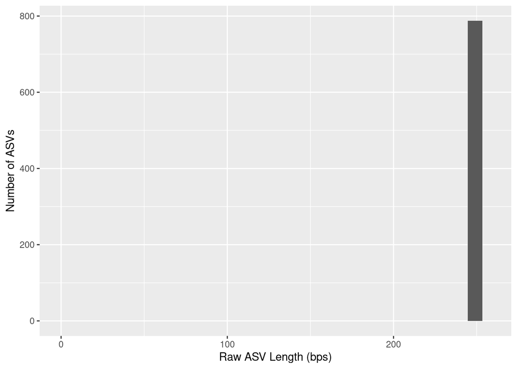

```r
# Inspect the distribution of sequence lengths of all ASVs in data set
# AFTER TRIM
plot_ASVLength_raw <-
  data.frame(Seq_Length = nchar(getSequences(raw_ASV_table))) %>%
  ggplot(aes(x = Seq_Length )) +
  geom_histogram() +
  # include the x-axis scales
  scale_x_continuous(limits = c(0, maxLength_ASV + 5)) +
  labs(y = "Number of ASVs", x = "Raw ASV Length (bps)")

# Show the plot
plot_ASVLength_raw
```

##Interpretation 2:

As we saw in the table, the length of the ASVs are 298 sequences that are 252 bps long and 490 sequences that are 253 bps long. This plot does confirm my hypothesis from Interpretation 1! All of the sequences retained were at (or one above) the expected bps length. Therefore, yes this matches my hypothesis for question 1 that the actual ASV length meets the expectations.

##Interpretation 3:

I decided I am not going to trim this data set because the sequence lengths are binned at 252 and 253 bps. I think they are close enough–with enough reads in each bin, to keep all the samples.

# Trim ASVs

```r
#Only pull ASVs that have a length of 245 bps
raw_ASV_table_trimmed <- raw_ASV_table[, nchar(getSequences(raw_ASV_table)) %in% c(252, 253)]

#Intuition check
table(nchar(getSequences(raw_ASV_table_trimmed)))
```

```
##
## 252 253
## 298 490
```

```r
# What proportion of total ASV sequences are left in the data?
percRetained_Trimmed <- sum(raw_ASV_table_trimmed)/sum(raw_ASV_table)
percRetained_Trimmed
```

```
## [1] 1
```

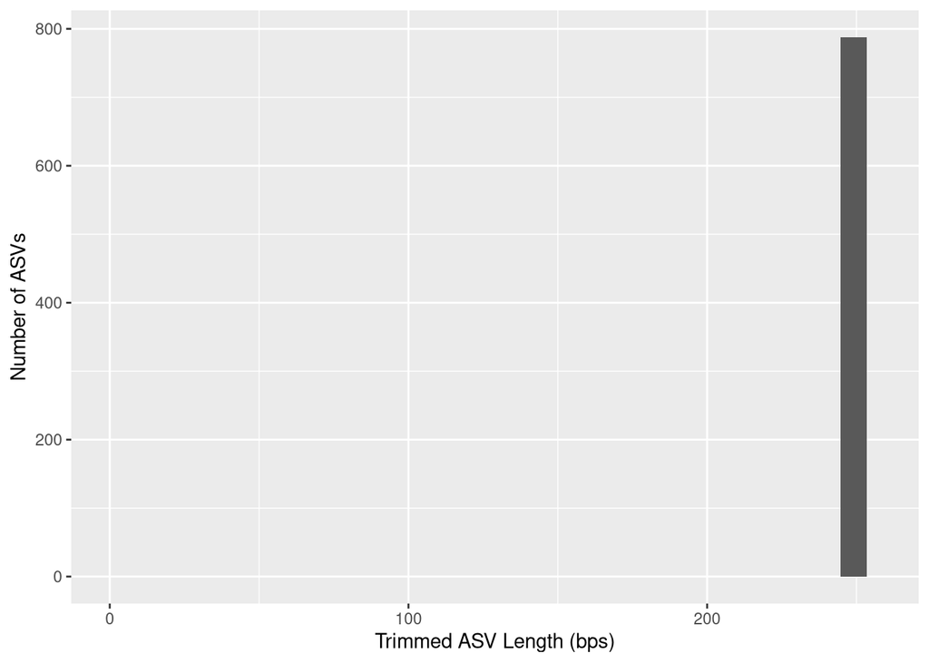

```r
# Inspect the distribution of sequence lengths of all ASVs in dataset
# AFTER TRIM
plot_ASVLength_trimmed <-
  data.frame(Seq_Length = nchar(getSequences(raw_ASV_table_trimmed))) %>%
  ggplot(aes(x = Seq_Length )) +
  geom_histogram() +
  # include the x-axis scales
  scale_x_continuous(limits = c(0, maxLength_ASV + 5)) +
  labs(y = "Number of ASVs", x = "Trimmed ASV Length (bps)")

# Show the plot
plot_ASVLength_trimmed
```

#Remove Chimeras

```r
# Remove the chimeras in the raw ASV table
noChimeras_ASV_table <- removeBimeraDenovo(raw_ASV_table_trimmed,
                                           method="consensus",
                                           multithread=TRUE, verbose=TRUE)
```

```
## Identified 695 bimeras out of 788 input sequences.
```

```r
# Check the dimensions
dim(noChimeras_ASV_table)
```

```
## [1] 20 93
```

```r
dim(raw_ASV_table_trimmed)
```

```
## [1]  20 788
```

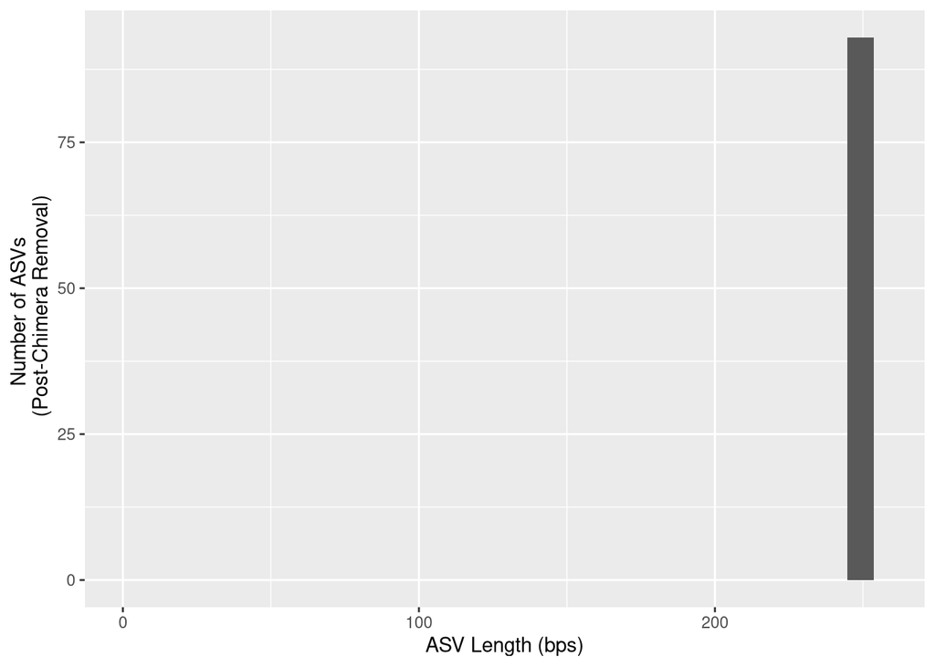

```r
#Difference tells us how many were cut from chimeras

# What proportion is left of the sequences?
percRetained_chimerasTrimmed <- sum(noChimeras_ASV_table)/sum(raw_ASV_table_trimmed)

percRetained_chimerasRaw <-sum(noChimeras_ASV_table)/sum(raw_ASV_table)

# Plot it
plot_ASVLength_NoChimeras <-
  data.frame(Seq_Length_NoChim = nchar(getSequences(noChimeras_ASV_table))) %>%
  ggplot(aes(x = Seq_Length_NoChim )) +
  geom_histogram()+
  # include the x-axis scales
  scale_x_continuous(limits = c(0, maxLength_ASV + 5)) +
  labs(y = "Number of ASVs \n (Post-Chimera Removal)",
       x = "ASV Length (bps)")

# Show the plot
plot_ASVLength_NoChimeras
```

##Interpretation 4:

There was 100% retention of ASVs after trimming because no sequences were trimmed! (per interpretation 3)

In the original raw ASV trimmed file, there were 788 sequences. After chimera removal there are 93. That is an 11.8% retention rate in ASVs after chimera removal which is very low.

Since no sequences were trimmed, this equates to an overall retention rate od 11.8% retention of ASVs after both filtering (even though there was no filtering) and chimera removal.

#Plot ASV Lengths

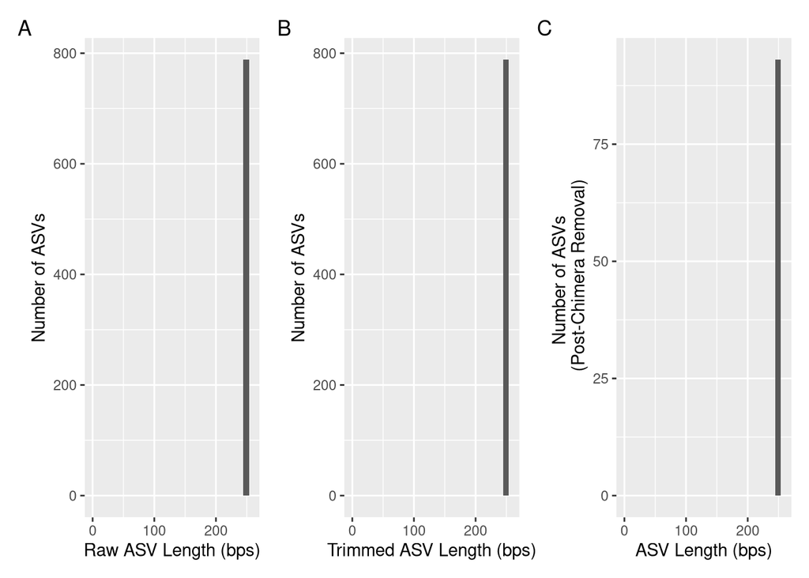

```r
plot_ASVLength_raw + plot_ASVLength_trimmed + plot_ASVLength_NoChimeras +
    plot_annotation(tag_levels = 'A')
```

#Track the read counts

```r
# A little function to identify number seqs
getN <- function(x) sum(getUniques(x))

# Make the table to track the seqs
track <- cbind(sapply(dada_forward, getN),
               sapply(dada_reverse, getN),
               sapply(merged_ASVs, getN),
               rowSums(noChimeras_ASV_table))

head(track)
```

```
##                                  [,1]  [,2]  [,3]  [,4]
## SRR9722160_R1_filtered.fastq.gz 37768 37746 35735 32004
## SRR9722161_R1_filtered.fastq.gz 69666 69661 64550 58676
## SRR9722162_R1_filtered.fastq.gz 66228 66215 61871 56254
## SRR9722163_R1_filtered.fastq.gz 63580 63583 60217 53609
## SRR9722164_R1_filtered.fastq.gz 75813 75711 70917 66632
## SRR9722165_R1_filtered.fastq.gz 68080 68056 63376 60147
```

```r
# Update column names to be more informative (most are missing at the moment!)
colnames(track) <- c("denoisedF", "denoisedR", "merged", "nochim")
rownames(track) <- row.names(noChimeras_ASV_table)

# Generate a dataframe to track the reads through our DADA2 pipeline
track_counts_df <-
  track %>%
  # make it a dataframe
  as.data.frame() %>%
  rownames_to_column(var = "sample_names")

# Now let's add a column for the number of ASVs
# First, intuition check that the samples match
stopifnot(track_counts_df$sample_names == row.names(noChimeras_ASV_table))

# Now, let's add a new column with the number of ASVs
track_counts_df <-
  track_counts_df %>%
  mutate(num_ASVs = rowSums(noChimeras_ASV_table > 1))

# Visualize it in table format
DT::datatable(track_counts_df)
```

|  | sample_names | denoisedF | denoisedR | merged | nochim | num_ASVs |
| --- | --- | --- | --- | --- | --- | --- |
| 1 | SRR9722160_R1_filtered.fastq.gz | 37768 | 37746 | 35735 | 32004 | 9 |
| 2 | SRR9722161_R1_filtered.fastq.gz | 69666 | 69661 | 64550 | 58676 | 12 |
| 3 | SRR9722162_R1_filtered.fastq.gz | 66228 | 66215 | 61871 | 56254 | 9 |
| 4 | SRR9722163_R1_filtered.fastq.gz | 63580 | 63583 | 60217 | 53609 | 14 |
| 5 | SRR9722164_R1_filtered.fastq.gz | 75813 | 75711 | 70917 | 66632 | 19 |
| 6 | SRR9722165_R1_filtered.fastq.gz | 68080 | 68056 | 63376 | 60147 | 19 |
| 7 | SRR9722166_R1_filtered.fastq.gz | 63976 | 63980 | 60678 | 53177 | 10 |
| 8 | SRR9722167_R1_filtered.fastq.gz | 57883 | 57882 | 54360 | 53007 | 9 |
| 9 | SRR9722168_R1_filtered.fastq.gz | 104524 | 104467 | 97812 | 90960 | 20 |
| 10 | SRR9722169_R1_filtered.fastq.gz | 61904 | 61893 | 57166 | 52907 | 20 |

[output cut: 10 more lines]

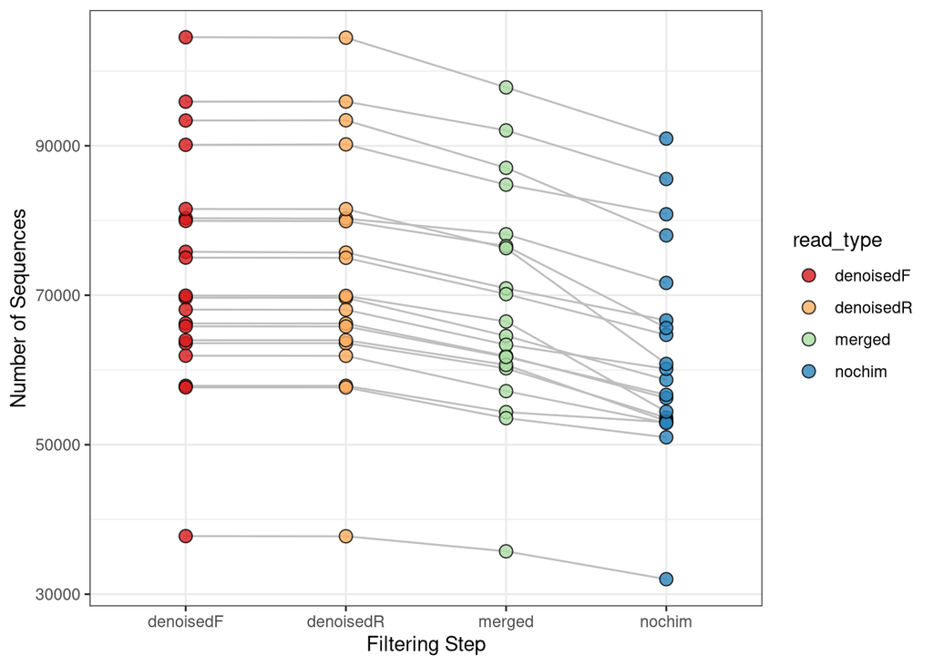

```r
# Plot it!
track_counts_df %>%
  pivot_longer(denoisedF:nochim, names_to = "read_type", values_to = "num_reads") %>%
  mutate(read_type = fct_relevel(read_type, "denoisedF", "denoisedR", "merged", "nochim")) %>%
  ggplot(aes(x = read_type, y = num_reads, fill = read_type)) +
  geom_line(aes(group = sample_names), color = "grey") +
  geom_point(shape = 21, size = 3, alpha = 0.8) +
  scale_fill_brewer(palette = "Spectral") +
  labs(x = "Filtering Step", y = "Number of Sequences") +
  theme_bw()
```

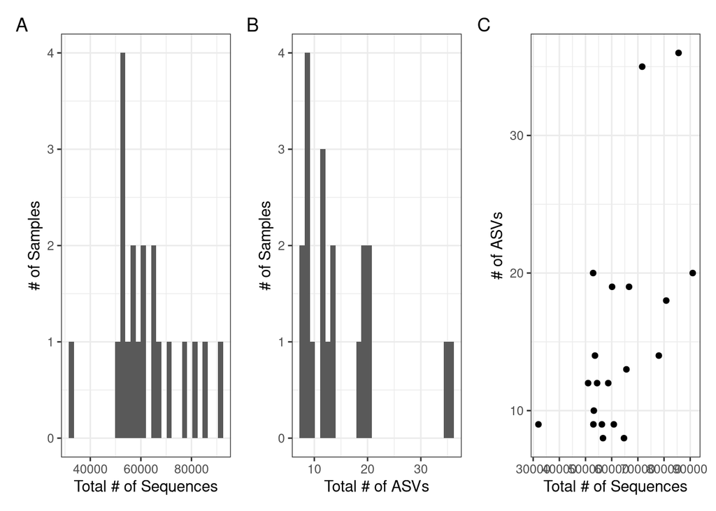

```r
plot_ReadDepth <-
  track_counts_df %>%
  ggplot(aes(x = nochim)) +
  geom_histogram() +
  labs(x = "Total # of Sequences", y = "# of Samples") +
  theme_bw()

# What is the ASV richness per sample?
plot_ASVRichness <-
  track_counts_df %>%
  ggplot(aes(x = num_ASVs)) +
  geom_histogram() +
  labs(x = "Total # of ASVs", y = "# of Samples") +
  theme_bw()

# Now, let's look at the relationship of ASVs and Sequencing depth
plot_ReadDepth_ASVRichness <-
  track_counts_df %>%
  ggplot(aes(x = nochim, y = num_ASVs)) +
  geom_point() +
  labs(x = "Total # of Sequences", y = "# of ASVs") +
  theme_bw()

# Show the plots together
plot_ReadDepth + plot_ASVRichness + plot_ReadDepth_ASVRichness +
    plot_annotation(tag_levels = 'A')
```

##Interpretation 5:

###Panel A : Read Depth After DADA2

-X-axis: Total number of sequences per sample (after filtering). -Y-axis: Number of samples with that read depth.

Looking at this graph, there is no real trend visible from the histogram. This can tell us a few things such as there are a lot of variability in sequencing depth across the samples. Some reads have over 60,000 reads and others have very low sequencing depth. This is important to know for down stream analysis that the data may not be reliable for diversity analysis. These problems could have stemmed from issues in the wet-lab with DNA extractions, PCR amplifications, or in the sequencing run.

###Panel B : ASV Richness After DADA2

-X-axis: Total number of ASVs per sample (unique amplicon sequence variants). -Y-axis: Number of samples with that ASV richness.

Like figure A, figure B has no clear distribution in the histogram. Most samples have low ASV richness (~10-30 ASVs per sample) and only a few samples have higher richenss which suggests that the samples have low microbial diversity–which checks out being that it is limited to Brazilian cheese samples. These differences in richness could potentially correspond with the meta data of cheese type.

###Panel C : Read Depth vs ASV Richness

-X-axis: Total number of sequences per sample. -Y-axis: Total number of ASVs detected.

While not a completely linear relationship, there does to be a positive relationship between read depth and ASV richness. Some high-read samples have low ASV richness. They may be dominated by a few species. For future analysis, rarefaction and the fact that there may be some dominant species may be important to remember when doing diversity metrics.

#Assigning Taxonomy

```r
# Assign up to genus level
taxa_train <-
  assignTaxonomy(noChimeras_ASV_table,
                 refFasta = "/local/workdir/in_class_data/taxonomy/silva_nr99_v138.2_toGenus_trainset.fa.gz",
                 multithread = n_threads)

# Add the genus/species information
taxa_addSpecies <-
  addSpecies(taxa_train,
              refFasta = "/local/workdir/in_class_data/taxonomy/silva_v138.2_assignSpecies.fa.gz")

# Inspect the taxonomy
glimpse(taxa_addSpecies) # Note that the rownames are the ASV sequences!
```

```
##  chr [1:93, 1:7] "Bacteria" "Bacteria" "Bacteria" "Bacteria" "Bacteria" ...
##  - attr(*, "dimnames")=List of 2
##   ..$ : chr [1:93] "TACGTAGGTCCCGAGCGTTGTCCGGATTTATTGGGCGTAAAGCGAGCGCAGGCGGTTTGATAAGTCTGAAGTTAAAGGCTGTGGCTCAACCATAGTTCGCTTTGGAAACTG"| __truncated__ "TACGTAGGTGGCAAGCGTTGTCCGGATTTATTGGGCGTAAAGCGAGCGCAGGCGGAATGATAAGTCTGATGTGAAAGCCCACGGCTCAACCGTGGAACTGCATCGGAAACT"| __truncated__ "TACGTAGGTCCCGAGCGTT…
##   ..$ : chr [1:7] "Kingdom" "Phylum" "Class" "Order" ...
```

```r
# Let's removing the ASV sequence rownames for display only
taxa_print <- taxa_addSpecies
rownames(taxa_print) <- NULL
head(taxa_print)
```

```
##      Kingdom    Phylum           Class                 Order
## [1,] "Bacteria" "Bacillota"      "Bacilli"             "Lactobacillales"
## [2,] "Bacteria" "Bacillota"      "Bacilli"             "Lactobacillales"
## [3,] "Bacteria" "Bacillota"      "Bacilli"             "Lactobacillales"
## [4,] "Bacteria" "Pseudomonadota" "Gammaproteobacteria" "Enterobacterales"
## [5,] "Bacteria" "Bacillota"      "Bacilli"             "Staphylococcales"
## [6,] "Bacteria" "Bacillota"      "Bacilli"             "Lactobacillales"
##      Family              Genus            Species
## [1,] "Streptococcaceae"  "Streptococcus"  NA
## [2,] "Lactobacillaceae"  "Lactobacillus"  NA
## [3,] "Streptococcaceae"  "Lactococcus"    NA
## [4,] "Yersiniaceae"      "Yersinia"       NA
## [5,] "Staphylococcaceae" "Staphylococcus" NA
## [6,] "Streptococcaceae"  "Streptococcus"  NA
```

```r
#View(taxa_print)
```

#Export the data

##1. ASV Tables

We will export the following two ASV count tables, which will be in “long” format where the ASVs are in rows and the sample names are in the columns.

###Structure of ASVs

Let’s check that the ASVs are in the rows and the sample names are in the columns. If not, we can use the transpose function t() in R.

```r
# What's the current format of the ASV table?
head(rownames(noChimeras_ASV_table)) # Samples!
```

```
## [1] "SRR9722160_R1_filtered.fastq.gz" "SRR9722161_R1_filtered.fastq.gz"
## [3] "SRR9722162_R1_filtered.fastq.gz" "SRR9722163_R1_filtered.fastq.gz"
## [5] "SRR9722164_R1_filtered.fastq.gz" "SRR9722165_R1_filtered.fastq.gz"
```

```r
head(colnames(noChimeras_ASV_table)) # ASV Sequences
```

```
## [1] "TACGTAGGTCCCGAGCGTTGTCCGGATTTATTGGGCGTAAAGCGAGCGCAGGCGGTTTGA…"
## [2] "TACGTAGGTGGCAAGCGTTGTCCGGATTTATTGGGCGTAAAGCGAGCGCAGGCGGAATGA…"
## [3] "TACGTAGGTCCCGAGCGTTGTCCGGATTTATTGGGCGTAAAGCGAGCGCAGGTGGTTTAT…"
## [4] "TACGGAGGGTGCAAGCGTTAATCGGAATTACTGGGCGTAAAGCGCACGCAGGCGGTTTGT…"
## [5] "TACGTAGGTGGCAAGCGTTATCCGGAATTATTGGGCGTAAAGCGCGCGTAGGCGGTTTCT…"
## [6] "TACGTAGGTGGCAAGCGTTGTCCGGATTTATTGGGCGTAAAGCGAGCGCAGGCGGTTTGA…"
```

```r
# Therefore, we need to transpose the matrix
final_ASV_table_withSeqs <- t(noChimeras_ASV_table)

# Intuition check
head(rownames(final_ASV_table_withSeqs)) # ASV Sequences
```

```
## [1] "TACGTAGGTCCCGAGCGTTGTCCGGATTTATTGGGCGTAAAGCGAGCGCAGGCGGTTTGA…"
## [2] "TACGTAGGTGGCAAGCGTTGTCCGGATTTATTGGGCGTAAAGCGAGCGCAGGCGGAATGA…"
## [3] "TACGTAGGTCCCGAGCGTTGTCCGGATTTATTGGGCGTAAAGCGAGCGCAGGTGGTTTAT…"
## [4] "TACGGAGGGTGCAAGCGTTAATCGGAATTACTGGGCGTAAAGCGCACGCAGGCGGTTTGT…"
## [5] "TACGTAGGTGGCAAGCGTTATCCGGAATTATTGGGCGTAAAGCGCGCGTAGGCGGTTTCT…"
## [6] "TACGTAGGTGGCAAGCGTTGTCCGGATTTATTGGGCGTAAAGCGAGCGCAGGCGGTTTGA…"
```

```r
head(colnames(final_ASV_table_withSeqs)) # Sample names
```

```
## [1] "SRR9722160_R1_filtered.fastq.gz" "SRR9722161_R1_filtered.fastq.gz"
## [3] "SRR9722162_R1_filtered.fastq.gz" "SRR9722163_R1_filtered.fastq.gz"
## [5] "SRR9722164_R1_filtered.fastq.gz" "SRR9722165_R1_filtered.fastq.gz"
```

###Names in ASV Tables

Fix Sample Names

```r
# Remember at the top of the file we created a vector of sample names
head(sample_names)
```

```
## [1] "SRR9722160" "SRR9722161" "SRR9722162" "SRR9722163" "SRR9722164"
## [6] "SRR9722165"
```

```r
# Let's check with the actual column names
head(colnames(final_ASV_table_withSeqs)) # Sample names
```

```
## [1] "SRR9722160_R1_filtered.fastq.gz" "SRR9722161_R1_filtered.fastq.gz"
## [3] "SRR9722162_R1_filtered.fastq.gz" "SRR9722163_R1_filtered.fastq.gz"
## [5] "SRR9722164_R1_filtered.fastq.gz" "SRR9722165_R1_filtered.fastq.gz"
```

```r
# And then apply our sample name script to check, too
head(sapply(strsplit(colnames(final_ASV_table_withSeqs), "_"), `[`,1)) # Looks good!
```

```
## [1] "SRR9722160" "SRR9722161" "SRR9722162" "SRR9722163" "SRR9722164"
## [6] "SRR9722165"
```

```r
# Now, add a break in the script break if this isn't true!
# Let's make sure the sample names match the file names in the matrix.
stopifnot(sapply(strsplit(colnames(final_ASV_table_withSeqs), "_"), `[`,1) == sample_names)

# Now, we've done some checks to prove to ourselves there will be no silent errors,
# Let's rename!
colnames(final_ASV_table_withSeqs) <- sample_names
head(colnames(final_ASV_table_withSeqs))
```

```
## [1] "SRR9722160" "SRR9722161" "SRR9722162" "SRR9722163" "SRR9722164"
## [6] "SRR9722165"
```

###Rename ASVs

Then, we can also fix the names of our ASVs for our second ASV table where we will replace the ASV sequence names with ASV_1, ASV_2 .

```r
# Give headers more manageable names
# First pull the ASV sequences from the rownames
ASV_seqs <- rownames(final_ASV_table_withSeqs)
ASV_seqs[1:5]
```

```
## [1] "TACGTAGGTCCCGAGCGTTGTCCGGATTTATTGGGCGTAAAGCGAGCGCAGGCGGTTTGA…"
## [2] "TACGTAGGTGGCAAGCGTTGTCCGGATTTATTGGGCGTAAAGCGAGCGCAGGCGGAATGA…"
## [3] "TACGTAGGTCCCGAGCGTTGTCCGGATTTATTGGGCGTAAAGCGAGCGCAGGTGGTTTAT…"
## [4] "TACGGAGGGTGCAAGCGTTAATCGGAATTACTGGGCGTAAAGCGCACGCAGGCGGTTTGT…"
## [5] "TACGTAGGTGGCAAGCGTTATCCGGAATTATTGGGCGTAAAGCGCGCGTAGGCGGTTTCT…"
```

```r
# How many ASVs?
num_ASVs <- dim(final_ASV_table_withSeqs)[1] # select the number of rows
num_ASVs
```

```
## [1] 93
```

```r
# Make an empty vector the length of the number of ASVs,
# which is where we will place the new operational ASV names
ASV_headers <- vector(num_ASVs, mode = "character")

# Let's mae sure we have an empty vector!
ASV_headers[1:5]
```

```
## [1] "" "" "" "" ""
```

```r
length(ASV_headers) # looks good!
```

```
## [1] 93
```

```r
# Now, let's create a vector with ASV numbers
# loop through vector and fill it in with ASV names
for (i in 1:num_ASVs) {
  # Add leading zero to ASV name so they print in correct order.
  ASV_number <- sprintf("%04d", i)
  # Now, rename each spot in the ASV header vector as we loop through the for loop
  ASV_headers[i] <- paste(">ASV", ASV_number, sep = "_")
}

# Intuition check
ASV_headers[1:5]
```

```
## [1] ">ASV_0001" ">ASV_0002" ">ASV_0003" ">ASV_0004" ">ASV_0005"
```

```r
# Create a new ASV table, which will have the ASV numbers as names
# View(noChimeras_ASV_table) # To view the table
final_ASV_table <- final_ASV_table_withSeqs
glimpse(final_ASV_table)
```

```
##  int [1:93, 1:20] 29902 1149 16 0 0 794 0 79 0 0 ...
##  - attr(*, "dimnames")=List of 2
##   ..$ : chr [1:93] "TACGTAGGTCCCGAGCGTTGTCCGGATTTATTGGGCGTAAAGCGAGCGCAGGCGGTTTGATAAGTCTGAAGTTAAAGGCTGTGGCTCAACCATAGTTCGCTTTGGAAACTG"| __truncated__ "TACGTAGGTGGCAAGCGTTGTCCGGATTTATTGGGCGTAAAGCGAGCGCAGGCGGAATGATAAGTCTGATGTGAAAGCCCACGGCTCAACCGTGGAACTGCATCGGAAACT"| __truncated__ "TACGTAGGTCCCGAGCGTT…
##   ..$ : chr [1:20] "SRR9722160" "SRR9722161" "SRR9722162" "SRR9722163" ...
```

```r
## Replace the ASV seqs with the ASV numbers
row.names(final_ASV_table) <- sub(">", "", ASV_headers)
final_ASV_table[1:5, 1:5]
```

```
##          SRR9722160 SRR9722161 SRR9722162 SRR9722163 SRR9722164
## ASV_0001      29902      50514      51179      45084      62329
## ASV_0002       1149       6390       3598       6782        376
## ASV_0003         16         45         43         22        568
## ASV_0004          0          0          0          0          0
## ASV_0005          0         18          0         15        281
```

```r
#View(final_ASV_table) # To view the table
```

###Write the ASV Tables

```r
# 1. Write count table with ASV sequence names
write.table(final_ASV_table_withSeqs,
            file = "/local/workdir/cjm423/milk-cheese-analysis/Milk-Cheese-Analysis/data/01_DADA2/ASV_table_withSeqNames.tsv",
            sep = "\t", quote = FALSE, col.names = NA)

# 2. Write count table with ASV numbered names (e.g. ASV_1, ASV_2, etc)
write.table(final_ASV_table,
            file = "/local/workdir/cjm423/milk-cheese-analysis/Milk-Cheese-Analysis/data/01_DADA2/ASV_table.tsv",
            sep = "\t", quote = FALSE, col.names = NA)
```

## 2. ASV FASTA File

Now, let’s create a fasta file that has our ASV numbers with each of their corresponding ASV sequences. This file needs to be created because we will use it later to build a phylogenetic tree.

###Write the ASV Fasta File

```r
 # Let's take our asv_headers
head(ASV_headers, n = 2)
```

```
## [1] ">ASV_0001" ">ASV_0002"
```

```r
head(ASV_seqs, n = 2)
```

```
## [1] "TACGTAGGTCCCGAGCGTTGTCCGGATTTATTGGGCGTAAAGCGAGCGCAGGCGGTTTGA…"
## [2] "TACGTAGGTGGCAAGCGTTGTCCGGATTTATTGGGCGTAAAGCGAGCGCAGGCGGAATGA…"
```

```r
# Combine in a fasta format with the cbind() function
ASV_fasta <- c(rbind(ASV_headers, ASV_seqs))
head(ASV_fasta, n = 4)
```

```
## [1] ">ASV_0001"
## [2] "TACGTAGGTCCCGAGCGTTGTCCGGATTTATTGGGCGTAAAGCGAGCGCAGGCGGTTTGA…"
## [3] ">ASV_0002"
## [4] "TACGTAGGTGGCAAGCGTTGTCCGGATTTATTGGGCGTAAAGCGAGCGCAGGCGGAATGA…"
```

```r
# Then, let's write it to a fasta file!
# This will be our reference later on for which seq matches which ASV
write(ASV_fasta, "/local/workdir/cjm423/milk-cheese-analysis/Milk-Cheese-Analysis/data/01_DADA2/ASVs.fasta")
```

## 3. Taxonomy Table

Before we actually write the taxonomy table, let’s put the ASV sequences as another column in our taxonomy table and then replace the rownames to be our numbered ASV names.

###Refortmat Taxonomy

1. Move ASV sequences to column
2. Replace ASV row names with ASV numbered names

```r
# Inspect the taxonomy table
dim(taxa_addSpecies) # ASVs are in rows and Kingdom, Phylum, etc in Columns
```

```
## [1] 93  7
```

```r
colnames(taxa_addSpecies) # Column names are Linnean Taxonomy
```

```
## [1] "Kingdom" "Phylum"  "Class"   "Order"   "Family"  "Genus"   "Species"
```

```r
head(rownames(taxa_addSpecies), n = 2) # ASV names are rownames
```

```
## [1] "TACGTAGGTCCCGAGCGTTGTCCGGATTTATTGGGCGTAAAGCGAGCGCAGGCGGTTTGA…"
## [2] "TACGTAGGTGGCAAGCGTTGTCCGGATTTATTGGGCGTAAAGCGAGCGCAGGCGGAATGA…"
```

```r
class(taxa_addSpecies) # Character matrix
```

```
## [1] "matrix" "array"
```

```r
##### Prepare tax table
# 1. Add the ASV sequences from the rownames to a column
new_tax_table <-
  taxa_addSpecies%>%
  as.data.frame() %>%
  rownames_to_column(var = "ASVseqs")

# Intuition check
glimpse(new_tax_table)
```

```
## Rows: 93
## Columns: 8
## $ ASVseqs <chr> "TACGTAGGTCCCGAGCGTTGTCCGGATTTATTGGGCGTAAAGCGAGCGCAGGCGGTTTGAT…
## $ Kingdom <chr> "Bacteria", "Bacteria", "Bacteria", "Bacteria", "Bacteria", "B…
## $ Phylum  <chr> "Bacillota", "Bacillota", "Bacillota", "Pseudomonadota", "Baci…
## $ Class   <chr> "Bacilli", "Bacilli", "Bacilli", "Gammaproteobacteria", "Bacil…
## $ Order   <chr> "Lactobacillales", "Lactobacillales", "Lactobacillales", "Ente…
## $ Family  <chr> "Streptococcaceae", "Lactobacillaceae", "Streptococcaceae", "Y…
## $ Genus   <chr> "Streptococcus", "Lactobacillus", "Lactococcus", "Yersinia", "…
## $ Species <chr> NA, NA, NA, NA, NA, NA, NA, NA, NA, NA, NA, NA, NA, NA, NA, "d…
```

```r
# IMPORTANT! Let's do our intuition check
# This is where we ensure we don't mix up the ASV names!
stopifnot(new_tax_table$ASVseqs == rownames(final_ASV_table_withSeqs))

# Now let's add the ASV names
rownames(new_tax_table) <- rownames(final_ASV_table)
head(new_tax_table)
```

```
##                                                                                                                                                                                                                                                                ASVseqs
## ASV_0001  TACGTAGGTCCCGAGCGTTGTCCGGATTTATTGGGCGTAAAGCGAGCGCAGGCGGTTTGA…
## ASV_0002 TACGTAGGTGGCAAGCGTTGTCCGGATTTATTGGGCGTAAAGCGAGCGCAGGCGGAATGA…
## ASV_0003  TACGTAGGTCCCGAGCGTTGTCCGGATTTATTGGGCGTAAAGCGAGCGCAGGTGGTTTAT…
## ASV_0004 TACGGAGGGTGCAAGCGTTAATCGGAATTACTGGGCGTAAAGCGCACGCAGGCGGTTTGT…
## ASV_0005 TACGTAGGTGGCAAGCGTTATCCGGAATTATTGGGCGTAAAGCGCGCGTAGGCGGTTTCT…
## ASV_0006  TACGTAGGTGGCAAGCGTTGTCCGGATTTATTGGGCGTAAAGCGAGCGCAGGCGGTTTGA…
##           Kingdom         Phylum               Class            Order
## ASV_0001 Bacteria      Bacillota             Bacilli  Lactobacillales
## ASV_0002 Bacteria      Bacillota             Bacilli  Lactobacillales
## ASV_0003 Bacteria      Bacillota             Bacilli  Lactobacillales
## ASV_0004 Bacteria Pseudomonadota Gammaproteobacteria Enterobacterales
## ASV_0005 Bacteria      Bacillota             Bacilli Staphylococcales
## ASV_0006 Bacteria      Bacillota             Bacilli  Lactobacillales
##                     Family          Genus Species
## ASV_0001  Streptococcaceae  Streptococcus    <NA>
## ASV_0002  Lactobacillaceae  Lactobacillus    <NA>
## ASV_0003  Streptococcaceae    Lactococcus    <NA>
## ASV_0004      Yersiniaceae       Yersinia    <NA>
## ASV_0005 Staphylococcaceae Staphylococcus    <NA>
## ASV_0006  Streptococcaceae  Streptococcus    <NA>
```

```r
### Final prep of tax table. Add new column with ASV names
ASV_tax_table <-
  new_tax_table %>%
  # add rownames from count table for phyloseq handoff
  mutate(ASV = rownames(final_ASV_table)) %>%
  # Reorder the columns
  dplyr::select(Kingdom, Phylum, Class, Order, Family, Genus, Species, ASV, ASVseqs)

# Assign the rownames, which is required by phyloseq
rownames(ASV_tax_table) <- ASV_tax_table$ASV

# Take a quick look
glimpse(ASV_tax_table)
```

```
## Rows: 93
## Columns: 9
## $ Kingdom <chr> "Bacteria", "Bacteria", "Bacteria", "Bacteria", "Bacteria", "B…
## $ Phylum  <chr> "Bacillota", "Bacillota", "Bacillota", "Pseudomonadota", "Baci…
## $ Class   <chr> "Bacilli", "Bacilli", "Bacilli", "Gammaproteobacteria", "Bacil…
## $ Order   <chr> "Lactobacillales", "Lactobacillales", "Lactobacillales", "Ente…
## $ Family  <chr> "Streptococcaceae", "Lactobacillaceae", "Streptococcaceae", "Y…
## $ Genus   <chr> "Streptococcus", "Lactobacillus", "Lactococcus", "Yersinia", "…
## $ Species <chr> NA, NA, NA, NA, NA, NA, NA, NA, NA, NA, NA, NA, NA, NA, NA, "d…
## $ ASV     <chr> "ASV_0001", "ASV_0002", "ASV_0003", "ASV_0004", "ASV_0005", "A…
## $ ASVseqs <chr> "TACGTAGGTCCCGAGCGTTGTCCGGATTTATTGGGCGTAAAGCGAGCGCAGGCGGTTTGAT…
```

```r
# Intution check
stopifnot(ASV_tax_table$ASV == rownames(ASV_tax_table),
          rownames(ASV_tax_table) == rownames(ASV_tax_table))
```

### Write the Taxonomy Table

Now, let’s write out the taxonomy table.

```r
# Write the table
write.table(ASV_tax_table,
            file = "/local/workdir/cjm423/milk-cheese-analysis/Milk-Cheese-Analysis/data/01_DADA2/ASV_taxonomy.tsv",
            sep = "\t", quote = FALSE, col.names = NA)
```

## 4. Sample Data

Let’s save the track_counts_df, which can be useful for downstream analyses.

```r
# And save the track_counts_df a R object, which we will merge with metadata information in the next step of the analysis in nalysis/02_Taxonomic_Assignment.
save(track_counts_df, file = "/local/workdir/cjm423/milk-cheese-analysis/Milk-Cheese-Analysis/data/01_DADA2/track_read_counts.RData")
```

# Session Information for Reproducibility

```r
#Time at the end of the script
end_time <- Sys.time()
end_time
```

```
## [1] "2025-03-09 16:29:33 EDT"
```

```r
#Echo the elapsed time
elapsed_time <- round((end_time - start_time), 3)
elapsed_time
```

```
## Time difference of 4.391 mins
```